# Who’s the most tragic NFL team?

Among teams that have had at least 30 playoff appearances since the 1966 season, the Vikings have the second-highest percentage of games that they lost unexpectedly.

These are games where ELO ratings indicated they had the advantage, but ultimately they lost.

Philadelphia Eagles have the highest percentage of playoff games lost unexpectedly

Even if you look at regular season games across the years, the Vikings are tied for 4th most unexpected losses.

However, looking at this over time shows that these unexpected losses have been less frequent in recent decades.

Interestingly, the playoff game against Atlanta in 1999 is the third biggest unexpected loss for the Vikings (68% probability for Vikings).

But that Saints game in January 2010 everybody talks about actually was one the Vikings weren’t expected to win (63% probability in favor of the Saints).

It’s not all doom and gloom ….the Vikings also have three of the biggest unexpected wins in a playoff game – the most impressive is 1987 season against San Francisco, where MIN (with a 21% probability rating) won the game 36-24. Only two bigger wins in playoff history both go to the Giants: beating Green Bay in 2011 playoffs (played in 2012); and beating the Patriots in the 2007 season Super Bowl (played in 2008). In 2004 season, Minnesota beat Green Bay in the wildcard round, 31-17 despite a probability of 25%.

Source: ELO ratings from FiveThirtyEight https://fivethirtyeight.com/features/how-our-2017-nfl-predictions-work/

```r
setwd("C:/Users/webstmj/OneDrive - Star Tribune/SuperBowl")

#install.packages("janitor")



# load required packages
library(readr) #importing csv files
library(plyr) #needed for stacked bar chart label positions
library(dplyr) #general analysis
library(ggplot2) #making charts
library(lubridate) #date functions
library(reshape2) #use this for melt function to create one record for each team
library(tidyr)
library(janitor) #use this for doing crosstabs

library(scales) #needed for stacked bar chart axis labels

#load data

elo <- read_csv("nfl_elo.csv")
```

```r
#prep data
#copy and rename team1 and team2 fields so can keep them in original data
elo_2<- elo%>%mutate(tm1=team1)%>%mutate(tm2=team2)
#reshape the data so there is one record for each team (original file is 1 per game)
elo_teams <- melt(elo_2, id=c("date", "season", "neutral", "playoff", "tm1", "tm2", "elo1_pre", "elo2_pre", "elo_prob1", "elo_prob2", "elo1_post", "elo2_post", "score1", "score2"))
#rename some fields
names(elo_teams)[names(elo_teams)=="value"] <- "teamname"
names(elo_teams)[names(elo_teams)=="date"] <- "gamedate"
names(elo_teams)[names(elo_teams)=="variable"] <-"teamtype"
#add a bunch of calculated fields
#Add decade, tiegame, winner, expected winner, Unexpected loss/win or expected outcome,
#team probability, opponent probability, probability difference
elo_teams <-  elo_teams%>%mutate(season_decade = year(floor_date(gamedate, years(10))))%>%
  mutate(tiegame = ifelse(score1==score2, "tie", "no tie"))%>%
  mutate(winner= ifelse(score1==score2, "tie", ifelse(score1>score2, tm1, tm2)))%>%
  mutate(expectwinner = ifelse(elo_prob1>elo_prob2, tm1, tm2))%>%
  mutate(outcome = ifelse(winner==expectwinner, "expected", ifelse(tiegame=="tie", "tie", ifelse(teamname==expectwinner, "unexpected loss","unexpected win"))))%>%
  mutate(teamprobability=ifelse(teamtype=="team1", elo_prob1, elo_prob2))%>%
  mutate(oppoprobability =ifelse(teamtype=="team1", elo_prob2, elo_prob1))%>%
  mutate(difference = teamprobability-oppoprobability)
```

```r
detach("package:plyr", unload=TRUE)
```

[output not shown]

```r
library(dplyr)
#teams by playoff games
playoffs <- elo_teams%>%filter(season>="1966", playoff!="NA")
playoffs2 <- playoffs%>%group_by(teamname, outcome)%>%summarise(count=n())%>%mutate(pct=(count/sum(count))*100)%>%mutate(totalgames=sum(count))
playoffs_30games <- playoffs2%>%filter(outcome=="unexpected loss", totalgames>=30)%>%arrange(desc(pct))
print("All playoff games - pct of unexpected losses by team")
```

```
[1] "All playoff games - pct of unexpected losses by team"
```

```r
playoffs2%>%filter(outcome=="unexpected loss") %>%arrange(desc(pct))
```

| teamname | outcome | count | pct | totalgames |
| --- | --- | --- | --- | --- |
| NO | unexpected loss | 5 | 31.250000 | 16 |
| LAC | unexpected loss | 7 | 30.434783 | 23 |
| PHI | unexpected loss | 10 | 28.571429 | 35 |
| MIN | unexpected loss | 11 | 23.404255 | 47 |
| CHI | unexpected loss | 5 | 21.739130 | 23 |
| CIN | unexpected loss | 4 | 21.052632 | 19 |
| OAK | unexpected loss | 9 | 20.454545 | 44 |
| KC | unexpected loss | 5 | 20.000000 | 25 |
| TB | unexpected loss | 3 | 20.000000 | 15 |
| DAL | unexpected loss | 12 | 19.672131 | 61 |

[output cut: 20 more lines]

[figure not shown]

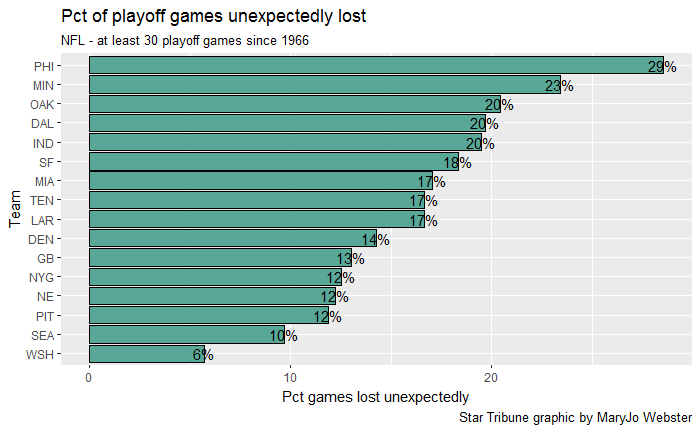

```r
#set the order of the bars ; this needs to come before you create hte chart
playoffs_30games$teamname <- factor(playoffs_30games$teamname, levels = playoffs_30games$teamname[order(playoffs_30games$pct)])
playoffs_30g_chart <- ggplot(playoffs_30games, aes(x = teamname, y = pct)) +
  geom_bar(stat = "identity", color="black", fill="#59A897") +
    geom_text(stat="identity", label=paste0(round(playoffs_30games$pct,0), "%"))+
    coord_flip() +
  labs(title = "Pct of playoff games unexpectedly lost",
       subtitle = "NFL - at least 30 playoff games since 1966",
       caption = "Star Tribune graphic by MaryJo Webster",
       x="Team",
       y="Pct games lost unexpectedly")
plot(playoffs_30g_chart)
```

```r
print("Percentage regular season games with unexpected losses")
```

```
[1] "Percentage regular season games with unexpected losses"
```

```r
reg_games_2%>%filter(outcome=="unexpected loss")%>%arrange(desc(pct))
```

| teamname | outcome | count | pct | totalgames |
| --- | --- | --- | --- | --- |
| DAL | unexpected loss | 164 | 20.55138 | 798 |
| PIT | unexpected loss | 162 | 20.30075 | 798 |
| DEN | unexpected loss | 153 | 19.17293 | 798 |
| MIN | unexpected loss | 152 | 19.04762 | 798 |
| WSH | unexpected loss | 152 | 19.04762 | 798 |
| NYG | unexpected loss | 151 | 18.92231 | 798 |
| GB | unexpected loss | 146 | 18.29574 | 798 |
| KC | unexpected loss | 146 | 18.29574 | 798 |
| PHI | unexpected loss | 146 | 18.29574 | 798 |
| BAL | unexpected loss | 64 | 18.28571 | 350 |

[output cut: 22 more lines]

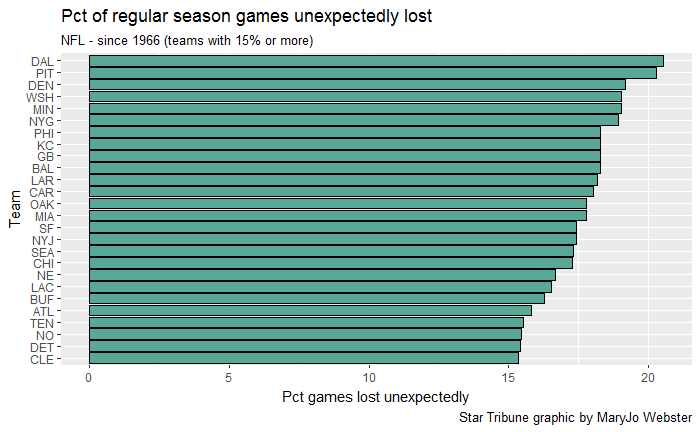

```r
reg_games_3 <-reg_games_2%>%filter(outcome=="unexpected loss", pct>=15)%>%arrange(desc(pct))
#set the order of the bars ; this needs to come before you create hte chart
reg_games_3$teamname <- factor(reg_games_3$teamname, levels = reg_games_3$teamname[order(reg_games_3$pct)])
reg_games_chart <- ggplot(reg_games_3, aes(x = teamname, y = pct)) +
  geom_bar(stat = "identity", color="black", fill="#59A897") +
  coord_flip() +
  labs(title = "Pct of regular season games unexpectedly lost",
       subtitle = "NFL - since 1966 (teams with 15% or more)",
       caption = "Star Tribune graphic by MaryJo Webster",
       x="Team",
       y="Pct games lost unexpectedly")
plot(reg_games_chart)
```

```r
#MIN and WSH tied for 4th place
```

[figure not shown]

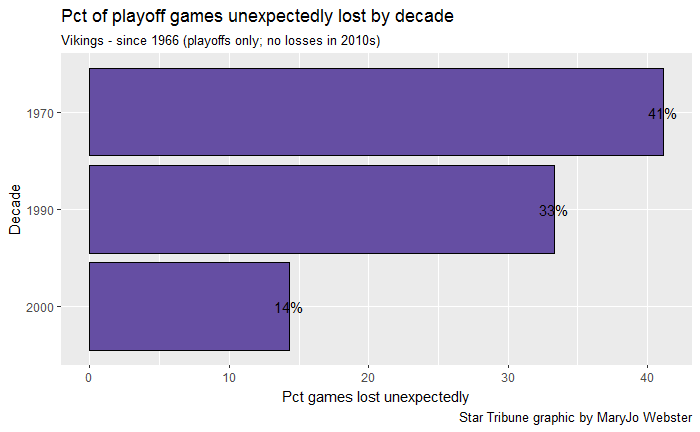

```r
vikings_playoffs_bydecade <- vikings%>%filter(playoff!="NA")%>%group_by(season_decade, outcome)%>%summarise(count=n())%>%mutate(pct=(count/sum(count))*100)%>%mutate(totalgames=sum(count))
vikings_playoffs_bydecade <-vikings_playoffs_bydecade%>%filter(outcome=="unexpected loss")%>%arrange(desc(pct))
#set the order of the bars ; this needs to come before you create hte chart
vikings_playoffs_bydecade$season_decade <-factor(vikings_playoffs_bydecade$season_decade,
                              levels=c("2010", "2000", "1990", "1980", "1970", "1960"))
vikings_playoffs_bydecade_chart <- ggplot(vikings_playoffs_bydecade, aes(x = season_decade, y = pct)) +
  geom_bar(stat = "identity", color="black", fill="#654ea3") +
   geom_text(stat="identity", label=paste0(round(vikings_playoffs_bydecade$pct,0), "%"))+
  coord_flip() +
  labs(title = "Pct of playoff games unexpectedly lost by decade",
       subtitle = "Vikings - since 1966 (playoffs only; no losses in 2010s)",
       caption = "Star Tribune graphic by MaryJo Webster",
       x="Decade",
       y="Pct games lost unexpectedly")
plot(vikings_playoffs_bydecade_chart)
```

```r
#there were no unexpected playoff LOSSES since 2010
```

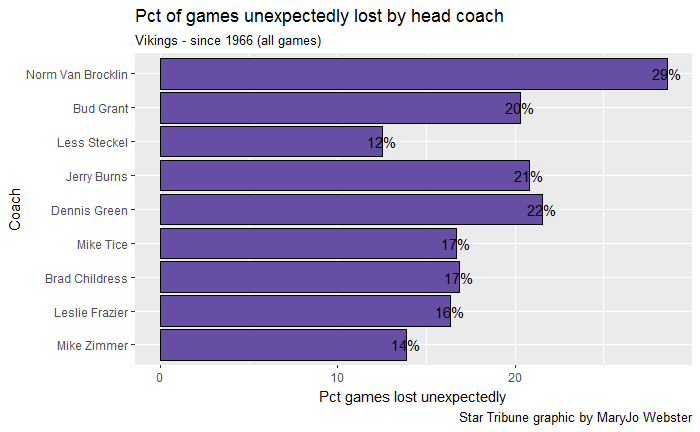

```r
vikings_bycoach <- vikings%>%group_by(`HEAD COACH`, outcome)%>%summarise(count=n())%>%mutate(pct=(count/sum(count))*100)%>%mutate(totalgames=sum(count))
vikings_bycoach <-vikings_bycoach%>%filter(outcome=="unexpected loss")%>%arrange(desc(pct))
#set the order of the bars ; this needs to come before you create hte chart
vikings_bycoach$`HEAD COACH` <-factor(vikings_bycoach$`HEAD COACH`,
                              levels=c("Mike Zimmer", "Leslie Frazier", "Brad Childress", "Mike Tice", "Dennis Green", "Jerry Burns", "Less Steckel", "Bud Grant", "Norm Van Brocklin"))
vikings_bycoach_chart <- ggplot(vikings_bycoach, aes(x = `HEAD COACH`, y = pct)) +
  geom_bar(stat = "identity", color="black", fill="#654ea3") +
   geom_text(stat="identity", label=paste0(round(vikings_bycoach$pct,0), "%"))+
  coord_flip() +
  labs(title = "Pct of games unexpectedly lost by head coach",
       subtitle = "Vikings - since 1966 (all games)",
       caption = "Star Tribune graphic by MaryJo Webster",
       x="Coach",
       y="Pct games lost unexpectedly")
plot(vikings_bycoach_chart)
```

Vikings - biggest playoff flops – expected to win by big margin, but lost

```r
#biggest playoff flops -- expected to win by big margin, but lost
vikings%>%filter(outcome=="unexpected loss", playoff!="NA")%>%select(season, playoff, `HEAD COACH`, tm1, tm2, score1, score2, teamprobability, oppoprobability, difference)%>%arrange(desc(difference))
```

| season | playoff | HEAD COACH | tm1 | tm2 | score1 | score2 | teamprobability | oppoprobability | difference |
| --- | --- | --- | --- | --- | --- | --- | --- | --- | --- |
| 1970 | d | Bud Grant | MIN | SF | 14 | 17 | 0.7497144 | 0.2502856 | 0.49942881 |
| 1994 | w | Dennis Green | MIN | CHI | 18 | 35 | 0.7023150 | 0.2976850 | 0.40463001 |
| 1998 | c | Dennis Green | MIN | ATL | 27 | 30 | 0.6865208 | 0.3134792 | 0.37304163 |
| 1975 | d | Bud Grant | MIN | DAL | 14 | 17 | 0.6750339 | 0.3249661 | 0.35006777 |
| 1971 | d | Bud Grant | MIN | DAL | 12 | 20 | 0.5970392 | 0.4029608 | 0.19407835 |
| 1992 | w | Dennis Green | MIN | WSH | 7 | 24 | 0.5799755 | 0.4200245 | 0.15995097 |
| 1976 | s | Bud Grant | OAK | MIN | 32 | 14 | 0.5758346 | 0.4241654 | 0.15166918 |
| 1969 | s | Bud Grant | MIN | KC | 7 | 23 | 0.5750119 | 0.4249881 | 0.15002373 |
| 1974 | s | Bud Grant | PIT | MIN | 16 | 6 | 0.5466610 | 0.4533390 | 0.09332199 |
| 2008 | w | Brad Childress | MIN | PHI | 14 | 26 | 0.5464384 | 0.4535616 | 0.09287688 |

[output cut: 1 more lines]

Vikings - biggest playoff victories – expected to lose, but didn’t

```r
#biggest playoff wins -- expected to lose, but didn't
vikings%>%filter(outcome=="unexpected win", playoff!="NA")%>%select(season, playoff, `HEAD COACH`, tm1, tm2, score1, score2, teamprobability, oppoprobability, difference)%>%arrange(difference)
```

| season | playoff | HEAD COACH | tm1 | tm2 | score1 | score2 | teamprobability | oppoprobability | difference |
| --- | --- | --- | --- | --- | --- | --- | --- | --- | --- |
| 1987 | d | Jerry Burns | SF | MIN | 24 | 36 | 0.2060238 | 0.7939762 | -0.58795233 |
| 1987 | w | Jerry Burns | NO | MIN | 10 | 44 | 0.2317881 | 0.7682119 | -0.53642389 |
| 2004 | w | Mike Tice | GB | MIN | 17 | 31 | 0.2484990 | 0.7515010 | -0.50300207 |
| 1977 | d | Bud Grant | LAR | MIN | 7 | 14 | 0.3030645 | 0.6969355 | -0.39387098 |
| 1997 | w | Dennis Green | NYG | MIN | 22 | 23 | 0.3311202 | 0.6688798 | -0.33775970 |
| 1973 | c | Bud Grant | DAL | MIN | 10 | 27 | 0.3963604 | 0.6036396 | -0.20727924 |
| 2009 | d | Brad Childress | MIN | DAL | 34 | 3 | 0.4871026 | 0.5128974 | -0.02579474 |

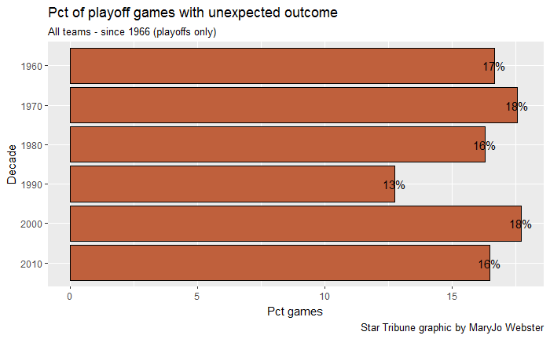

```r
#IDEAS
#stacked bar with percentage unexpected loss, unexpected win and expected outcome -- for playoff games across time
allteams_bydecade <- elo_teams%>%filter(season>="1966", playoff!="NA", outcome!="NA")%>%group_by(season_decade, outcome)%>%summarise(count=n())%>%mutate(pct=(count/sum(count))*100)%>%mutate(totalgames=sum(count))
allteams_bydecade2 <- allteams_bydecade%>%filter(outcome=="unexpected loss")%>%arrange(desc(pct))
#set the order of the bars ; this needs to come before you create hte chart
allteams_bydecade2$season_decade <-factor(allteams_bydecade2$season_decade,
                              levels=c("2010", "2000", "1990", "1980", "1970", "1960"))
allteams_bydecade2_chart <- ggplot(allteams_bydecade2, aes(x = season_decade, y = pct)) +
  geom_bar(stat = "identity", color="black", fill="#BF603C") +
  geom_text(stat="identity", label=paste0(round(allteams_bydecade2$pct,0), "%"))+
  coord_flip() +
  labs(title = "Pct of playoff games with unexpected outcome",
       subtitle = "All teams - since 1966 (playoffs only)",
       caption = "Star Tribune graphic by MaryJo Webster",
       x="Decade",
       y="Pct games")
plot(allteams_bydecade2_chart)
```

```r
#directions for stacked bar below: http://t-redactyl.io/blog/2016/01/creating-plots-in-r-using-ggplot2-part-4-stacked-bar-plots.html
#this makes a stacked bar chart but uses allteams_bydecade as the data frame
```

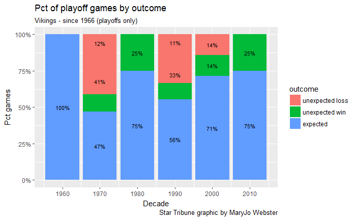

```r
#detach("package:plyr", unload=TRUE)
library(dplyr)
vikings_stacked <- vikings%>%filter(playoff!="NA", outcome!="NA")%>%group_by(season_decade, outcome)%>%
    summarise(count=n())%>%
    mutate(pct=(count/sum(count))*100)%>%
    mutate(totalgames=sum(count))
library(plyr)
vikings_stacked$outcome <-factor(vikings_stacked$outcome,
                              levels=c("unexpected loss", "unexpected win", "expected"))
vikings_stacked <- ddply(vikings_stacked, .(season_decade),
                           transform, pos=cumsum(pct) - (0.5 * pct))
vikings_stacked_chart <- ggplot() + geom_bar(aes(y=pct, x=season_decade, fill=outcome), data=vikings_stacked, stat="identity") +
  geom_text(data=vikings_stacked, aes(x=season_decade, y=pos, label=paste0(round(pct,0), "%")), size=3) +
  scale_x_continuous(breaks=seq(1960,2010,10))+
  scale_y_continuous(labels=dollar_format(suffix="%", prefix=""))+
    labs(title = "Pct of playoff games by outcome",
       subtitle = "Vikings - since 1966 (playoffs only)",
       caption = "Star Tribune graphic by MaryJo Webster",
       x="Decade",
       y="Pct games")
plot(vikings_stacked_chart)
```

All teams – biggest unexpected losses in playoff games (teamname indicates the losing team) Notice that Minnesota is more often the unexpected winner than the unexpected loser

| season | playoff | teamname | winner | tm1 | tm2 | score1 | score2 | teamprobability | oppoprobability | difference |
| --- | --- | --- | --- | --- | --- | --- | --- | --- | --- | --- |
| 2011 | d | GB | NYG | GB | NYG | 20 | 37 | 0.8176520 | 0.1823480 | 0.635304001 |
| 2007 | s | NE | NYG | NYG | NE | 17 | 14 | 0.8062273 | 0.1937727 | 0.612454665 |
| 1987 | d | SF | MIN | SF | MIN | 24 | 36 | 0.7939762 | 0.2060238 | 0.587952331 |
| 1996 | d | DEN | JAX | DEN | JAX | 27 | 30 | 0.7899235 | 0.2100765 | 0.579846953 |
| 1983 | w | DAL | LAR | DAL | LAR | 17 | 24 | 0.7827732 | 0.2172268 | 0.565546366 |
| 1987 | w | NO | MIN | NO | MIN | 10 | 44 | 0.7682119 | 0.2317881 | 0.536423886 |
| 1937 | c | CHI | WSH | CHI | WSH | 21 | 28 | 0.7597186 | 0.2402814 | 0.519437111 |
| 1998 | w | DAL | ARI | DAL | ARI | 7 | 20 | 0.7549070 | 0.2450930 | 0.509813962 |
| 2004 | w | GB | MIN | GB | MIN | 17 | 31 | 0.7515010 | 0.2484990 | 0.503002071 |
| 1970 | d | MIN | SF | MIN | SF | 14 | 17 | 0.7497144 | 0.2502856 | 0.499428809 |

[output cut: 165 more lines]

Heartbreak almost-upset games – games Vikings were expected to lose, but came really close to winning

| season | playoff | tm1 | tm2 | score1 | score2 | winner | teamprobability | scorediff |
| --- | --- | --- | --- | --- | --- | --- | --- | --- |
| 2015 | w | MIN | SEA | 9 | 10 | SEA | 0.4387225 | 1 |
| 2009 | c | NO | MIN | 31 | 28 | NO | 0.3693126 | 3 |
| 1987 | c | WSH | MIN | 17 | 10 | WSH | 0.3121317 | 7 |
| 1993 | w | NYG | MIN | 17 | 10 | NYG | 0.3632664 | 7 |
| 1968 | d | IND | MIN | 24 | 14 | IND | 0.1531610 | 10 |
| 1999 | d | LAR | MIN | 49 | 37 | LAR | 0.4893593 | 12 |
| 2004 | d | PHI | MIN | 27 | 14 | PHI | 0.2843383 | 13 |
| 1982 | d | WSH | MIN | 21 | 7 | WSH | 0.2471919 | 14 |
| 2012 | w | GB | MIN | 24 | 10 | GB | 0.2795358 | 14 |
| 1980 | d | PHI | MIN | 31 | 16 | PHI | 0.2378311 | 15 |

[output cut: 7 more lines]

Heartbreak losses – games Vikings were expected to WIN, but they lost by narrow margin

| season | playoff | tm1 | tm2 | score1 | score2 | winner | teamprobability | scorediff |
| --- | --- | --- | --- | --- | --- | --- | --- | --- |
| 1970 | d | MIN | SF | 14 | 17 | SF | 0.7497144 | 3 |
| 1975 | d | MIN | DAL | 14 | 17 | DAL | 0.6750339 | 3 |
| 1998 | c | MIN | ATL | 27 | 30 | ATL | 0.6865208 | 3 |
| 1971 | d | MIN | DAL | 12 | 20 | DAL | 0.5970392 | 8 |
| 1974 | s | PIT | MIN | 16 | 6 | PIT | 0.5466610 | 10 |
| 2008 | w | MIN | PHI | 14 | 26 | PHI | 0.5464384 | 12 |
| 1969 | s | MIN | KC | 7 | 23 | KC | 0.5750119 | 16 |
| 1973 | s | MIN | MIA | 7 | 24 | MIA | 0.5398450 | 17 |
| 1992 | w | MIN | WSH | 7 | 24 | WSH | 0.5799755 | 17 |
| 1994 | w | MIN | CHI | 18 | 35 | CHI | 0.7023150 | 17 |

[output cut: 1 more lines]